# Analysis of the performance of APC propellers in the engine O.S. 55 AX type glow

## Importing data

The data here comes from performance [files](https://www.apcprop.com/technical-information/performance-data/) on APC's website.

```python
models = {'13x4' : '13x4.dat.txt',
          '12x6' : '12x6.dat.txt',
          '12x4' : '12x4.dat.txt',
          '12.25x3.75' : '1225x375.dat.txt',
          '11x7' : '11x7.dat.txt',
          '11.5x6' : '115x6.dat.txt',
          '11.5x4' : '115x4.dat.txt'}

data = []
count=1
for i in models.keys():
    print('Model ', i, 'imported succefully.')
    cache = read_txt(models[i], i)
    cache = SI_dataframe(cache)
    data.append(cache)
    if count==len(models):
        print('All files read succefully, Data Imported.')
    count+=1
df = pd.concat(data, ignore_index=True)
```

```
Model  13x4 imported succefully.
Erros de NAN:
 Velocity (mph)     0
J (Adv Ratio)      0
Pe                 0
Ct                 0
Cp                 0
PWR (Hp)           0
Torque (In-Lbf)    0
Thrust(Lbf)        0
RPM                0
dtype: int64

Model  12x6 imported succefully.
Erros de NAN:
 Velocity (mph)     0
J (Adv Ratio)      0
Pe                 1
Ct                 1
Cp                 1
PWR (Hp)           1
Torque (In-Lbf)    1
Thrust(Lbf)        0
RPM                1
dtype: int64

Model  12x4 imported succefully.
Erros de NAN:
 Velocity (mph)     0
J (Adv Ratio)      0
Pe                 1
Ct                 1
Cp                 1
PWR (Hp)           1
Torque (In-Lbf)    1
Thrust(Lbf)        0
RPM                1
dtype: int64

Model  12.25x3.75 imported succefully.
```

[output cut: 37 more lines]

```

Model  11.5x4 imported succefully.
Erros de NAN:
 Velocity (mph)     0
J (Adv Ratio)      0
Pe                 0
Ct                 0
Cp                 0
PWR (Hp)           0
Torque (In-Lbf)    0
Thrust(Lbf)        0
RPM                0
dtype: int64

All files read succefully, Data Imported.
```

```python
df
```

|  | Velocity (m/s) | J (Adv Ratio) | Pe | Ct | Cp | PWR (W) | Torque (N/m) | Thrust (N) | Frequency (Hz) | Model |
| --- | --- | --- | --- | --- | --- | --- | --- | --- | --- | --- |
| 0 | 0.000000 | 0.00 | 0.0000 | 0.0738 | 0.0239 | 0.746 | 0.004858 | 0.289134 | 16.666667 | 13x4 |
| 1 | 0.089408 | 0.02 | 0.0545 | 0.0723 | 0.0240 | 0.746 | 0.004858 | 0.284686 | 16.666667 | 13x4 |
| 2 | 0.178816 | 0.04 | 0.1064 | 0.0708 | 0.0240 | 0.746 | 0.004971 | 0.275790 | 16.666667 | 13x4 |
| 3 | 0.312928 | 0.05 | 0.1557 | 0.0692 | 0.0241 | 0.746 | 0.004971 | 0.271342 | 16.666667 | 13x4 |
| 4 | 0.402336 | 0.07 | 0.2023 | 0.0675 | 0.0241 | 0.746 | 0.004971 | 0.266893 | 16.666667 | 13x4 |
| ... | ... | ... | ... | ... | ... | ... | ... | ... | ... | ... |
| 4008 | 46.939200 | 0.46 | 0.3796 | 0.0216 | 0.0261 | 2916.860 | 1.325651 | 23.575577 | 350.000000 | 11.5x4 |
| 4009 | 48.816768 | 0.48 | 0.3302 | 0.0165 | 0.0239 | 2674.410 | 1.215491 | 18.077574 | 350.000000 | 11.5x4 |
| 4010 | 50.694336 | 0.50 | 0.2519 | 0.0112 | 0.0221 | 2466.276 | 1.121149 | 12.250403 | 350.000000 | 11.5x4 |
| 4011 | 52.571904 | 0.51 | 0.1442 | 0.0057 | 0.0202 | 2260.380 | 1.027484 | 6.196373 | 350.000000 | 11.5x4 |
| 4012 | 54.449472 | 0.53 | -0.0018 | -0.0001 | 0.0184 | 2057.468 | 0.935062 | -0.066723 | 350.000000 | 11.5x4 |

4013 rows × 10 columns

## Performance analysis

### What is the maximum power delivered to the propellers by the O.S. 55 AX engine?

A [Senior project](https://drive.google.com/file/d/1x9uZG-elibI31o7J-3XOLMaI9HKNXmgI/view?usp=sharing) was found that shows the maximum frequency values for two of these propellers on that engine, models **12.25 x 3.75 and 13x4**, to be **206.25 Hz and 192.3834 Hz** respectively.

With that, the maximum power, at these frequencies in these models, was found to be **736,302 W and 741,524 W** and the average of the two, **738,913 W**, was taken as the maximum power delivered by the engine.

```python
df1=0
df1 = df.groupby('Model')
df1 = df1.get_group('12.25x3.75')
df1 = df1[(df1['Frequency (Hz)'] <= 206.25)]
max_power_1225x375 = df1['PWR (W)'].max()

df1=0
df1 = df.groupby('Model')
df1 = df1.get_group('13x4')
df1 = df1[(df1['Frequency (Hz)'] <= 192.3834)]
max_power_13x4 = df1['PWR (W)'].max()

max_power = np.mean([max_power_1225x375, max_power_13x4])
```

Afterwards, all entries with power greater than max power were removed from the dataframe.

```python
dfs=[]
cache = 0
for i in models.keys():
    df1=0
    df1=df.groupby('Model')
    df1 = df1.get_group(i)
    df1=df1[(df1['PWR (W)'] <= max_power)]
    df1 = df1.groupby('Frequency (Hz)')
    cache = df1.size()
    cache = cache.sort_index(ascending=False)
    best_frequency = cache.idxmax()
    df1 = df1.get_group(best_frequency)
    dfs.append(df1)
df1 = pd.concat(dfs)
```

```python
df1
```

|  | Velocity (m/s) | J (Adv Ratio) | Pe | Ct | Cp | PWR (W) | Torque (N/m) | Thrust (N) | Frequency (Hz) | Model |
| --- | --- | --- | --- | --- | --- | --- | --- | --- | --- | --- |
| 270 | 0.000000 | 0.00 | 0.0000 | 0.0782 | 0.0252 | 539.358 | 0.514646 | 30.697180 | 166.666667 | 13x4 |
| 271 | 0.983488 | 0.02 | 0.0557 | 0.0766 | 0.0248 | 531.898 | 0.507415 | 30.069981 | 166.666667 | 13x4 |
| 272 | 1.966976 | 0.04 | 0.1105 | 0.0749 | 0.0244 | 524.438 | 0.500297 | 29.407196 | 166.666667 | 13x4 |
| 273 | 2.950464 | 0.05 | 0.1642 | 0.0732 | 0.0241 | 516.978 | 0.493179 | 28.713273 | 166.666667 | 13x4 |
| 274 | 3.933952 | 0.07 | 0.2165 | 0.0713 | 0.0238 | 509.518 | 0.486174 | 27.988213 | 166.666667 | 13x4 |
| ... | ... | ... | ... | ... | ... | ... | ... | ... | ... | ... |
| 3738 | 27.716480 | 0.47 | 0.7061 | 0.0173 | 0.0116 | 243.196 | 0.193204 | 6.187477 | 200.000000 | 11.5x4 |
| 3739 | 28.834080 | 0.49 | 0.6530 | 0.0131 | 0.0099 | 206.642 | 0.164393 | 4.679530 | 200.000000 | 11.5x4 |
| 3740 | 29.906976 | 0.51 | 0.5579 | 0.0088 | 0.0081 | 168.596 | 0.134339 | 3.144893 | 200.000000 | 11.5x4 |
| 3741 | 31.024576 | 0.53 | 0.3741 | 0.0044 | 0.0063 | 131.296 | 0.104511 | 1.583567 | 200.000000 | 11.5x4 |
| 3742 | 32.142176 | 0.55 | -0.0021 | 0.0000 | 0.0046 | 95.488 | 0.076152 | -0.004448 | 200.000000 | 11.5x4 |

210 rows × 10 columns

## The following is the actual analysis

### Thurst velocity plots for all the propellers

One of the fundamental ways to measure performance of propellers is to assess their performance in low velocities, (below takeoff velocity) since a higher thrust in these velocities can mean a faster acceleration a reduced runway length.

The figure below show that it is quite clear that the 12.25 x 3.75 model is the best performing one in this set.

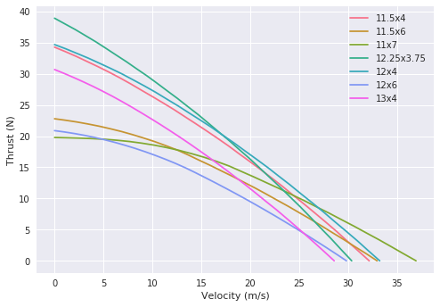

```python
APCplot(df=df1, group='Model', x='Velocity (m/s)', y='Thrust (N)')
```

### Finding the coefficients of this curve

We can find the coefficients of the thrust curve (T) as a function of velocity (v) assuming a quadratic relationship and applying a least squares method, the following is the equation with the relationship and the sum of squares of the errors.

$$T(v) = -0.014436v^{2} + -0.845198v + 38.942274 \quad error = 0.010472$$

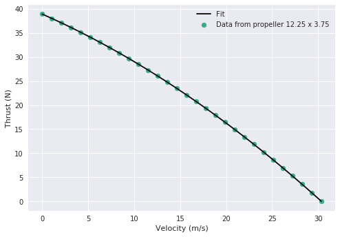

```python
grouped = 0
grouped = df1.groupby('Model')
x=np.arange(0, 40, step=0.01)


coef = np.polyfit(grouped.get_group('12.25x3.75')['Velocity (m/s)'], grouped.get_group('12.25x3.75')['Thrust (N)'], 2, full=True)
#print('v^%f + v*%f + %f, erro = %f' % (coef[0][0], coef[0][1], coef[0][2], coef[1]))
fit = np.polyval(coef[0] , x)
fit = fit[fit>=0]
x = x[0:len(fit)]


plt.scatter(grouped.get_group('12.25x3.75')['Velocity (m/s)'], grouped.get_group('12.25x3.75')['Thrust (N)'], label='Data from propeller 12.25 x 3.75', color=sns.color_palette('husl', 7)[3])
plt.plot(x, fit, label='Fit', color='k')
plt.legend()
plt.xlabel('Velocity (m/s)')
plt.ylabel('Thrust (N)')
plt.savefig('fig_4.png', dpi=100)
plt.show()
```

## Efficiency of a propeller

The formal definition of the efficiency (𝜂) of a propeller is fraction of the power it delivers in relation to the power recieved by the engine: $$\eta=\frac{{P}_{effective}}{{P}_{engine}}$$

In this case calculated with the available data, as defined by the bibliographic reference of the suplier [UIUC](https://m-selig.ae.illinois.edu/props/propDB.html):

D being the diameter of the propeller, 𝜌 the density of the air and n the frequency in revolutions per second, one can define the coefficients of thrust ($C_{t}$) and power ($C_{p}$) as: ${C}_{t} = \frac{T}{\rho {n}^{2} {D}^{4}}$ and ${C}_{p} = \frac{P}{\rho {n}^{3} {D}^{5}}$

With that, 𝜂 can be written as: $$\eta=\frac{{C}_{t}J}{{C}_{p}}$$

### Efficiency as function of the advance ratio (J)

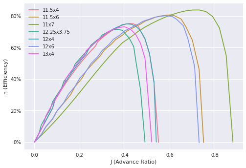

```python
APCplot(df=df1, group='Model', x='J (Adv Ratio)', y='Pe',
       xlabel='J (Advance Ratio)', ylabel = 'η (Efficiency)',
       percent_y = True, save_at = 'fig_2.png')
```

### Efficiency as a function of thrust

As you can see in the figure above, the propellers all have relatively high efficiencies (above 60%).

The 12.25 x 3.75 model was chosen, even though it had the lowest efficiency of all, 71.56%, for having an efficiency above the values set as acceptable in the literature (above 60%) and for having the largest area in the thrust-efficiency curve. This is due to an inverse relationship between these two variables as shown in the Figure below.

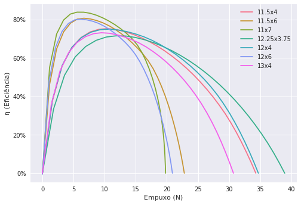

```python
APCplot(df=df1, group='Model', x='Thrust (N)', y='Pe',
       xlabel='Empuxo (N)', ylabel = 'η (Eficiência)',
       percent_y = True, save_at = 'fig_3.png')
```